# Module 4: Missing data and dropout in longitudinal studies

Aya Mitani

## Missing responses in longitudinal studies

- Except in highly controlled settings, missing data in longitudinal studies are inevitable
- What are the implications for missing data?
  - Create complications for methods that require **balanced** data
  - Reduce the **precision** with which changes in the mean response over time can be estimated
  - Can introduce **bias** and lead to misleading inferences about changes in the mean response
- Statistical methods to account for missing data in correlated (longitudinal) data is still a rapidly developing field
- Usually, the missing data mechanism is not under the control of the investigators
- We make **assumptions** about the missing data mechanism
- Validity of the analysis depends on whether these assumptions hold
- We need to be **explicit** about the assumptions made regarding the reasons for missing data

## Missing data pattern

Largely, two types of missing data pattern exist in longitudinal studies:

#### Monotone missing data pattern

- Arises from **dropout**
- The term dropout refers to the special case where if $Y_{ik}$ is missing, then $Y_{ik+1},...,Y_{in}$ are also missing
- Key question: Do individuals that dropout and those that remain in the study differ in any further relevant way?

#### Intermittent (non-monotone) missing data pattern

- Missing data pattern that is not monotone

## Ex: Clinical trial of contracepting women

- This is a longitudinal clinical trial of contracepting women
- Women received an injection of either 100 mg or 150 mg of depot-mderoxyprogesterone acetate (DMPA) on the day of randomization and three additional injections at 90-day intervals
- Final follow-up visit occurred at 90 days after the fourth injection (one year after the first injection)
- Women completed menstrual diaries throughout the study
- The outcome of interest was experience of amenorrhea, which is the absence of menstrual bleeding, in the four successive three-month intervals
- There was substantial dropout in this clinical trial

| Variable | Value | Description |
| --- | --- | --- |
| id | Numeric | Subject ID |
| trt | Numeric | Treatment dose (0 = 100mg, 1 = 150mg of DMPA) |
| time | Numeric | 1,2,3,4 for the four consecutive 90-day injection intervals |
| y | Numeric | Experience of amenorrhea |

## Ex: Clinical trial of contracepting women

```r
amen <- read.table(here("datasets", "amenorrhea.txt"), header = TRUE)

# change to wide format to use md.pattern() function from mice package
amen %>%
  pivot_wider(names_from = time,
              names_prefix = "y",
              values_from = y) %>%
  dplyr::select(-id, -trt) %>%
  md.pattern()
```

```
    y1  y2  y3  y4
714  1   1   1   1   0
84   1   1   1   0   1
155  1   1   0   0   2
198  1   0   0   0   3
     0 198 353 437 988
```

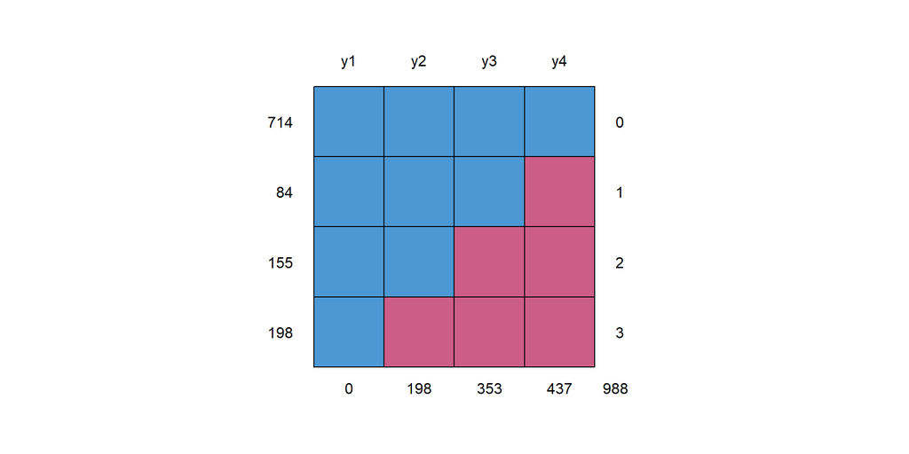

- Monotone missing data pattern
- 714 women have complete responses
- 198 women dropped out after the first visit
- 155 women dropped out after the second visit
- 84 women dropped out after the third visit

## Missing data notation

Suppose we have $n$ repeated measurements of the same individual. Then, the $i$th subject’s set of responses can be represented as a $n \times 1$ vector denoted by
$$Y_{i} = (Y_{i1}, Y_{i2}, ..., Y_{in})^{T}.$$
In the missing data literature, the response vector $Y_{i}$ is coupled with a $n \times 1$ vector of **response indicators**
$$R_{i} = (R_{i1}, R_{i2}, ..., R_{in})^{T},$$
where $R_{ij} = 1$ if $Y_{ij}$ is observed and $R_{ij} = 0$ is $Y_{ij}$ is missing.

Given $R_{i}$, we can **partition** $Y_{i} = (Y_{i1}, Y_{i2}, ..., Y_{in})^{T}$ into two components $Y_{i}^{O}$ and $Y_{i}^{M}$ where

- $Y_{i}^{O}$ denotes the vector of **observed** responses for subject $i$
- $Y_{i}^{M}$ denotes the vector of **missing** responses for subject $i$

## Missing data mechanism

#### Missing completely at random (MCAR)

- Probability that responses are missing is unrelated to both the set of observed responses ($Y_{i}^{O}$) and the value that should have been obtained ($Y_{i}^{M}$)
- $\Pr(R_{i}|Y_{i}^{O}, Y_{i}^{M}, X_{i}) = \Pr(R_{i})$

#### Missing at random (MAR)

- Probability that responses are missing depends on the set of observed responses ($Y_{i}^{O}$) but is conditionally unrelated to the values that should have been obtained ($Y_{i}^{M}$)
- $\Pr(R_{i}|Y_{i}^{O}, Y_{i}^{M}, X_{i}) = \Pr(R_{i}|Y_{i}^{O}, X_{i})$

#### Missing not at random (MNAR)

- Probability that responses are missing depends on the set of observed responses ($Y_{i}^{O}$) and the values that should have been obtained ($Y_{i}^{M}$)
- $\Pr(R_{i}|Y_{i}^{O}, Y_{i}^{M}, X_{i})$ or $\Pr(R_{i}|Y_{i}^{M}, X_{i})$
- For **likelihood-based inference**, the crucial distinction is between MCAR/MAR and MNAR
  - i.e. for likelihood-based methods, valid inferences can still be obtained even if data are MAR

# Inverse probability weighting

## Inverse probability weighting

- Basic idea is to estimate the probability of individuals remaining (or dropping out) in the study and weigh each observation according to that probability
  - Individuals with low probability of remaining in the study (high probability of dropping out) are given larger weights
  - Individuals with high probability of remaining in the study (low probability of dropping out) are given smaller weights
- IPW methods are more straightforward to implement with **monotone** missing data pattern
- IPW methods are more appealing when a full likelihood-based analysis is not possible
  - i.e. marginal analysis with discrete responses
  - IPW is often incorporated into **GEE**
- Requires correct specification of the dropout model
  - $\Pr(R_{ij}=1|R_{i1}=\cdots R_{i,j-1}, X_{i}, Y_{i1},...,Y_{i,j-1})$

## IPW-GEE

The IPW-GEE estimator is obtained as the solution to the following **weighted** estimating equations:

$$\sum_{i=1}^{N}D_{i}^{T}V_{i}^{-1}W_{i}(Y_{i}-\mu)=0,$$

where

- $D_{i}$ is the $n \times p$ derivative matrix
- $V_{i}$ is a $n \times n$ working covariance matrix for $Y_{i}$
- $W_{i}$ is a $n \times n$ **diagonal** matrix of the occasion-specific weights, $w_{ij}$, for $j = 1,...,n$,
  $$W_{i}=
  \left(\begin{array}{cccc}
  R_{i1}\times w_{i1} & 0 & ... & 0\\
  0 & R_{i2}\times w_{i2} & ... & 0\\
  \vdots & \vdots & \ddots & \vdots \\
  0 & 0 & ... & R_{in}\times w_{in}
  \end{array}\right)$$

## IPW-GEE

To calculate these weights, let $\pi_{ij}$ denote the **conditional** probability of the $i$th individual being observed (or not dropping out) at the $j$th occasion, given that this individual was observed at the prior occasions.

For the first occasion we usually assume $R_{i1}=1$ for all individuals, and then $\pi_{i1}=1$.

The MAR assumption implies that
$$\pi_{ij}=\Pr(R_{ij}=1|R_{i1}= \cdots = R_{i,j-1}=1, Y_{i1}= \cdots = Y_{i,j-1}, X_{i}).$$

The **unconditional** probability of being observed at the $j$th occasion can be expressed as the **cumulative product** of **conditional** probabilities,
$$\pi_{i1} \times \pi_{i2} \times \cdots \times \pi_{ij}.$$
The required weight is then given by the **inverse** of the cumulative product of conditional probabilities,
$$w_{ij} = (\pi_{i1} \times \pi_{i2} \times \cdots \times \pi_{ij})^{-1}.$$

## Estimation of weights

We can estimate $\pi_{ij}$ by constructing a logistic regression model for $\pi_{ij}$:

$$\begin{aligned}
\text{logit}(\pi_{ij}) &= \text{logit}\left\{\Pr(R_{ij}=1|R_{i1}=\cdots=R_{i,j-1}=1,Z_{ij})\right\}\\
&= Z_{ij}^{T}\theta
\end{aligned}$$
where $Z_{ij}$ is a $q \times 1$ design vector that incorporates:

- certain components of $X_{ij}$
- past responses ($Y_{i1},...,Y_{i,j-1}$)
- possibly additional covariates that may be predictive of dropout but are not of subject-matter interest in the marginal model for the mean response

## Assumptions

- The missing data mechanism depends only on **variables fully observed** in the sample
- The probability of being observed ($\pi_{ij}$) is **positive** (not close to zero)
  - If $\pi_{ij}$ is very small, $w_{ij}$ will be extremely large
  - Extremely large weights on small subset of observations may yield regression parameter estimates that are unstable and have poor precision
- Safest to assume working **independence** correlation
  - Need robust standard errors using the sandwich variance estimator

## Detailed approach with data from Clinical trial of contracepting women

We are interested in modeling the **marginal** probability of amenorrhea:
$$\text{logit}(\mu_{ij})=\beta_{1} + \beta_{2}t_{ij} + \beta_{3}t^{2}_{ij} + \beta_{4}\text{Dose}_{i} + \beta_{5}(t_{ij} \times \text{Dose}_{i})+ \beta_{6}(t^{2}_{ij} \times \text{Dose}_{i})$$

- Because we are interested in modeling the marginal probability of a **discrete** (or more specifically, binary) outcome, we cannot employ ML methods
- We need to fit a marginal model using GEE
  - Estimates will be biased if data are MAR
- Incorporate IPW

## Model for dropout process

- First, we will fit a model for the dropout process
- The outcome is $\text{logit}(\pi_{ij}) = \text{logit}\left\{\Pr(R_{ij}=1)\right\}$
  - Although it is called “dropout model”, we are modeling the probability of **not** dropping out
  - We don’t include baseline data (everybody is observed)
- The predictors include fully observed covariates and previously observed responses

$$\begin{align}
\text{logit}(\pi_{ij})=\theta_{1}+\theta_{2}I(t=2)+\theta_{3}I(t=3)+\theta_{4}\text{Dose}_{i}+\theta_{5}Y_{i,j-1}&+\theta_{6}(\text{Dose}_{i}\times Y_{i,j-1}), \\ j &= 1,2,3
\end{align}$$
where $\pi_{ij}=\Pr(R_{ij}=1|R_{i1}= \cdots = R_{i,j-1}=1, Y_{i,j-1}, \text{Dose}_{i})$.

## Model for dropout process

```r
# ipw
ipwdat <- amen %>%
  group_by(id) %>%
  mutate(prevy = lag(y)) %>%
  ungroup() %>%
  mutate(r = ifelse(is.na(y), 0, 1),
         t2 = ifelse(time == 2, 1, 0),
         t3 = ifelse(time == 3, 1, 0),
         trt.prevy = trt * prevy) %>%
  filter(!is.na(y)|!is.na(prevy))
tail(ipwdat, 10)
```

```
# A tibble: 10 × 12
      id   trt  time     y time2 trt.time trt.time2 prevy     r    t2    t3
   <int> <int> <dbl> <int> <dbl>    <dbl>     <dbl> <int> <dbl> <dbl> <dbl>
 1  1149     1     2     1     4        2         4     1     1     1     0
 2  1149     1     3     1     9        3         9     1     1     0     1
 3  1150     1     0     1     0        0         0    NA     1     0     0
 4  1150     1     1     1     1        1         1     1     1     0     0
 5  1150     1     2     1     4        2         4     1     1     1     0
 6  1150     1     3     1     9        3         9     1     1     0     1
 7  1151     1     0     1     0        0         0    NA     1     0     0
 8  1151     1     1     1     1        1         1     1     1     0     0
 9  1151     1     2     1     4        2         4     1     1     1     0
10  1151     1     3     1     9        3         9     1     1     0     1
# ℹ 1 more variable: trt.prevy <int>
```

## Model for dropout process

```r
# fit drop-out model
r <- ipwdat$r
xmat <- as.matrix(
  cbind(rep(1, length(r)),
        ipwdat[,c("t2", "t3", "trt", "prevy", "trt.prevy")])
  )
rmod <- glm(r ~ xmat, family = binomial("logit"))
```

## Model for dropout process

```r
summary(rmod)$coef; dropcoef <- summary(rmod)$coef[,1]
```

```
                 Estimate Std. Error    z value     Pr(>|z|)
(Intercept)    1.66811222  0.1043728 15.9822506 1.698994e-57
xmatt2         0.13671067  0.1190086  1.1487459 2.506608e-01
xmatt3         0.72861424  0.1438667  5.0645105 4.094510e-07
xmattrt        0.06796897  0.1312673  0.5177906 6.046044e-01
xmatprevy     -0.45139587  0.1618999 -2.7881167 5.301545e-03
xmattrt.prevy -0.23810242  0.2195678 -1.0844141 2.781812e-01
```

## Compute IPW

First, compute the predicted $\text{logit}(\hat\pi_{ij})$ from the dropout model.
$$\begin{align}
\text{logit}(\hat\pi_{ij})&=\hat\theta_{1}+\hat\theta_{2}I(t=2)+\hat\theta_{3}I(t=3)+\hat\theta_{4}\text{Dose}_{i}+\hat\theta_{5}Y_{i,j-1}+\hat\theta_{6}(\text{Dose}_{i}\times Y_{i,j-1}) \\
&=Z_{ij}^{T}\hat\theta
\end{align}$$

```r
ipwdat <- ipwdat %>%
  mutate(logitp = as.numeric(xmat %*% dropcoef))
```

## Compute IPW

Then, compute the predicted $\hat\pi_{ij}$.

$$\hat\pi_{ij} = \frac{\text{exp}(Z_{ij}^{T}\hat\theta)}{1+\text{exp}(Z_{ij}^{T}\hat\theta)}$$

```r
ipwdat <- ipwdat %>%
  mutate(logitp = as.numeric(xmat %*% dropcoef),
         phat = ifelse(time == 0, 1, exp(logitp) / (1 + exp(logitp))))
```

Finally, compute the visit-specific IPW as

$$\hat w_{ij} = (\hat\pi_{i1} \times \hat\pi_{i2} \times \cdots \hat\pi_{ij})^{-1}.$$

## Compute IPW

Because the first response was fully observed, with $R_{ij}=1$ for all individuals, $\hat\pi_{i1} = 1$ by definition.

```r
ipwdat <- ipwdat %>%
  mutate(logitp = as.numeric(xmat %*% dropcoef),
         phat = ifelse(time == 0, 1, exp(logitp) / (1 + exp(logitp)))) %>%
  group_by(id) %>%
  mutate(cumprob = cumprod(phat),
         ipw = 1/cumprob) %>%
  ungroup()
```

## Compute IPW

```r
ipwdat %>%
  filter(id %in% c(100, 200, 400, 1000)) %>%
  dplyr::select(id, trt, time, y, prevy, r, logitp, phat, cumprob, ipw) %>%
  print()
```

```
# A tibble: 13 × 10
      id   trt  time     y prevy     r logitp  phat cumprob   ipw
   <int> <int> <dbl> <int> <int> <dbl>  <dbl> <dbl>   <dbl> <dbl>
 1   100     1     0     0    NA     1  NA    1       1      1
 2   100     1     1    NA     0     0   1.74 0.850   0.850  1.18
 3   200     0     0     0    NA     1  NA    1       1      1
 4   200     0     1     0     0     1   1.67 0.841   0.841  1.19
 5   200     0     2    NA     0     0   1.80 0.859   0.722  1.38
 6   400     1     0     0    NA     1  NA    1       1      1
 7   400     1     1     0     0     1   1.74 0.850   0.850  1.18
 8   400     1     2     1     0     1   1.87 0.867   0.737  1.36
 9   400     1     3    NA     1     0   1.78 0.855   0.630  1.59
10  1000     1     0     0    NA     1  NA    1       1      1
11  1000     1     1     1     0     1   1.74 0.850   0.850  1.18
12  1000     1     2     1     1     1   1.18 0.766   0.651  1.54
13  1000     1     3     1     1     1   1.78 0.855   0.557  1.80
```

## Compute IPW

Prior to conducting an IPW-GEE analysis, we should examine the **distribution** of the estimated weights for any presence of discernibly large weights.

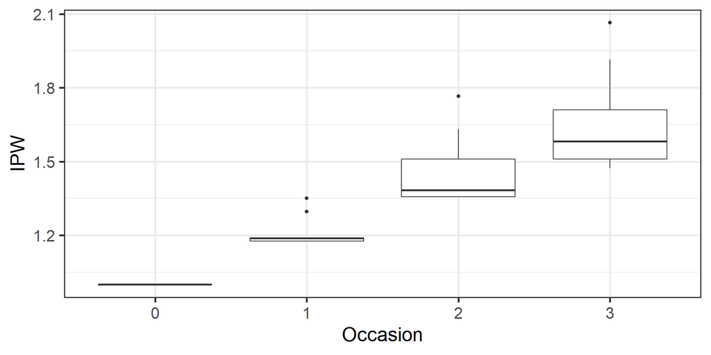

- $\hat w_{i1}=1$ for all individuals, as should be
- Estimated weights are increasing over time
- Estimated weights range from 1.0 to 2.1 $\rightarrow$ no concern that a small subset of the observations might have undue influence on the analysis

## Model for response with IPW

Finally, we will fit a logistic regression model for the marginal probability of amenorrhea:
$$\text{logit}(\mu_{ij})=\beta_{1} + \beta_{2}t_{ij} + \beta_{3}t^{2}_{ij} + \beta_{4}\text{Dose}_{i} + \beta_{5}(t_{ij} \times \text{Dose}_{i})+ \beta_{6}(t^{2}_{ij} \times \text{Dose}_{i})$$

- Use `wights=` option in `geeglm`
- To ensure that the weights are appropriately incorporated, we need to make the **“working independence”** assumption for the within-subject association among the responses
- Because a “working independence” assumption is made, standard errors are based on the **sandwich variance** estimator (default for `geeglm`)

## Comparison

- We will compare $\hat\beta_{5}$ and $\hat\beta_{6}$ from **four** different analyses
  - Complete-case analysis
  - Available data analysis
  - Last observation carried forward
  - IPW

Estimated regression coefficients (standard errors) from logistic regression analysis

| Variable | Complete-case | Available data | Last value carried fwd | IPW |
| --- | --- | --- | --- | --- |
| Effective number of obs | 2856 | 3616 | 3616 | 3616 |
| Time x Dose | 0.610 | 0.436 | 0.386 | 0.409 |
|  | (0.228) | (0.188) | (0.154) | (0.191) |
| Time^2 x Dose | -0.169 | -0.134 | -0.114 | -0.126 |
|  | (0.066) | (0.057) | (0.043) | (0.058) |

## Summary

- IPW is useful if only the response variables are missing due to dropout
- IPW requires correct specification of the dropout model for valid estimation of $\beta$
- In the presence of discernibly large weights,
  - Check the sensitivity of results to the inclusion of observations that receive large weights
  - If the analysis results are sensitive to a small number of large weights, then
    - apply weight truncation
    - rebuild a new dropout model
    - or consider an alternative methods of adjusting for missingness

# Joint models (JM) for longitudinal and time-to-event data

## Motivation

- In longitudinal follow-up studies, **missing data** is inevitable
  - Subjects drop out or do not adhere to scheduled visit times
  - Monotone or intermittent missing data
- When the probability of a subject dropping out depends on their unobserved longitudinal measurements, then the dropout process is defined as **missing not at random** or **informative**
  - This process cannot be ignored (**nonignorable**), and valid inferences can only be made based on a joint distribution of the longitudinal measurements and the missingness process
- JM provides a solution to both problems: **endogeneity** and **informative missingness**
  - The relative risk model for the time-to-event outcome depends on the true underlying values of the longitudinal outcome
  - The estimation is based on the joint distribution of the two outcomes

## General concepts of JM

- JMs are applicable in settings where subjects are **followed-up over time**
  - e.g. to monitor the progress of a disease or medical condition
- The **progression** of the disease or condition is typically evaluated via repeated measurements of a biomarker
  - e.g. CD4 cell counts in HIV patients
- It is also of scientific interest to determine the effect of such a biomarker on the **time to an event** of interest
  - e.g. death or development of cancer
- The biomarker measurements are **endogenous** or **internal**: the value at any given time point is dependent on the occurrence of the event prior to that time point
- They are usually **measured with error** and the value is only known for the specific time points at which it is measured

## The standard joint model

- To account for the special features of endogenous time-varying covariates a new class of models has been developed
  - Joint models for longitudinal and time-to-event data
- Intuitive ideas behind JM
  - Use an appropriate model to describe the **evolution** of the time-dependent covariate for each patient over time while taking into account the **complex time functions** and **measurement errors**
  - The **estimated evolution** are then used in a Cox model
  - The time-dependent covariate is not assumed constant between visits

## Notations for the standard JM

- $T_i^{*}$: **True** event time for subject $i$
- $T_i$: **Observed** event time for subject $i$
- $\delta_i$: Event indicator
- $y_i(t)$: Longitudinal response for subject $i$ at time $t$
  - Note that we do not actually observe $y_i(t)$ for any time $t$, but rather only at the very specific occasions $t_{ij}$ at which measurements were taken
  - The **observed** longitudinal data consist of measurements $y_{ij}=\{y_i(t_{ij}), j=1,...,n_i\}$

## The survival submodel

- Our aim is to measure the association between the longitudinal marker level and the risk for an event
- We introduce $m_i(t)$ that denotes the **true** and **unobserved** value of the longitudinal outcome at $t$
  - $m_i(t) \neq y_i(t)$ because $y_i(t)$ is **observed** and contaminated with measurement error
- Then, to quantify the strength of association between $m_i(t)$ and the risk for an event, we define the hazard model
  $$h_i(t|\mathcal{M}_i(t)) = h_0(t)\exp\{\gamma^{T}w_i+\alpha m_i(t)\}$$
  where
  - $\mathcal{M}_i(t) = \{m_i(s), 0 \leq s \le t\}$ is the longitudinal history
  - $\alpha$ quantifies the strength of association between $m_i(t)$ and the risk for an event
  - $w_i$ are the baseline covariates

## The longitudinal submodel

- We need to **estimate** $m_i(t)$ and reconstruct the complete longitudinal history $\mathcal{M}_i(t)$ for each subject
- Use the **observed** longitudinal response $y_i(t)$ in a linear mixed effects model
  $$\begin{aligned}
  y_i(t) &= m_i(t) + \epsilon_i(t) \\
  &= x_i^{T}(t)\beta + z_i^{T}(t)b_i + \epsilon_i(t), \qquad \epsilon_i(t) \sim \mathcal{N}(0, \sigma^2)
  \end{aligned}$$
  where
  - $x_i(t)$ and $\beta$ account for the fixed part of the model
  - $z_i(t)$ and $b_i$ account for the random part of the model with $b_i \sim \mathcal{N}(0,D)$
- The mixed effects model accounts for the measurement error problem by postulating that $y_i(t)$ equals $m_i(t)$ plus a random error term ($\epsilon_i(t)$)
- The time structure in $x_i(t)$ and $z_i(t)$, and the **subject-specific random effects** ($b_i$) allows to reconstruct the complete path of $\mathcal{M}_i(t)$
- It is important to obtain a good estimate of $\mathcal{M}_i(t)$
  - The longitudinal submodel can be quite complex

## The joint model

- Finally, the two submodels are associated by defining a model for their **joint distribution**

$$p(y_i, T_i, \delta_i) = \int p(y_i|b_i)\{h(T_i|b_i)^{\delta_i}S(T_i|b_i)\}p(b_i)db_i$$
where

- $b_i$ is a vector of random effects that explains the interdependencies
  - **between** the longitudinal and time-to-event process
  - **within** the longitudinal process
- $p(\cdot)$ is the density function
- $S(\cdot)$ is the survival function

## Assumptions of JM

- **Full conditional independence**
  - random effects explain all interdependencies
  - conditional on the random effects
    - the longitudinal outcome and the time-to-event outcome are independent
    - the repeated measurements in the longitudinal outcome are independent of each other
- The censoring and visiting processes are assumed **non-informative**
- **Decision to withdraw** from the study or **to appear** at the next visit
  - may depend on the **observed** past history
  - no additional dependence on underlying, latent subject characteristics associated with prognosis

## Example: AIDS data

- Study participants: 467 HIV infected patients who had failed or were intolerant to zidovudine therapy (AZT) (Abrams et al., NEJM, 1994)
- Primary aim: to compare the efficacy and safety of two alternative antiretroviral drugs, didanosine (ddI) and zalcitabine (ddC) in time to death
  - 230 patients randomized to ddI and 237 to ddC
- Our focus: to study the association between CD4 cell counts and the risk for death
  - Time-to-event outcome: time to death
  - Longitudinal outcome: CD4 cell counts measured at baseline, 2, 6, 12, 18 months

## Data structure

- There are two types of AIDS data set in the `JM` package

```r
library(JM)
data(aids)
data(aids.id)
```

- `aids.id`
  - A data frame with 467 observations and 12 variables
  - One observation for each patient
  - Contains the first CD4 cell count measurement for each patient
  - Used to fit the **survival submodel**

```r
head(aids.id, 20)
```

```
   patient  Time death       CD4 obstime drug gender prevOI         AZT start
1        1 16.97     0 10.677078       0  ddC   male   AIDS intolerance     0
2        2 19.00     0  6.324555       0  ddI   male noAIDS intolerance     0
3        3 18.53     1  3.464102       0  ddI female   AIDS intolerance     0
4        4 12.70     0  3.872983       0  ddC   male   AIDS     failure     0
5        5 15.13     0  7.280110       0  ddI   male   AIDS     failure     0
6        6  1.90     1  4.582576       0  ddC female   AIDS     failure     0
7        7 14.33     0  6.782330       0  ddC   male   AIDS intolerance     0
8        8  9.57     1  3.464102       0  ddI female noAIDS intolerance     0
9        9 11.57     1  0.000000       0  ddC   male   AIDS     failure     0
10      10 16.43     0 12.124356       0  ddI   male   AIDS intolerance     0
11      11  2.40     1  6.855655       0  ddC   male   AIDS intolerance     0
12      12 18.10     0 13.601471       0  ddI   male noAIDS intolerance     0
13      13 12.23     1  2.449490       0  ddC   male noAIDS intolerance     0
14      14  2.60     1  2.000000       0  ddI   male noAIDS intolerance     0
```

[output cut: 27 more lines]

## Survival probability

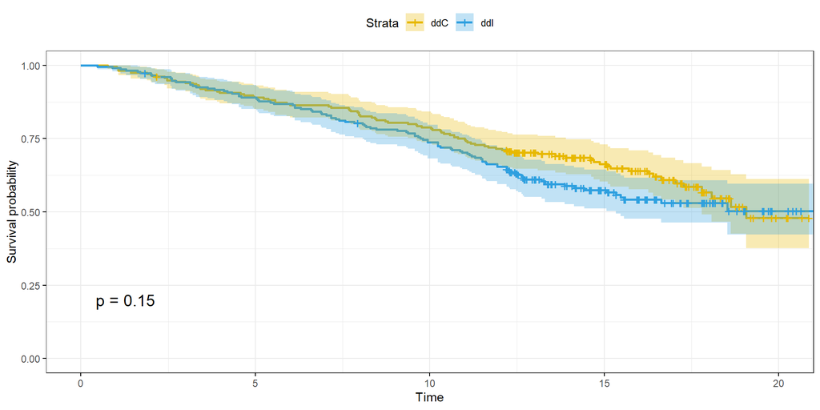

## Data structure

- `aids`
  - A data frame with 1405 observations and 12 variables
  - Multiple observation for each patient
  - Contains all CD4 cell count measurement for each patient
  - Used to fit the **longitudinal submodel**

```r
head(aids, 20)
```

```
   patient  Time death       CD4 obstime drug gender prevOI         AZT start
1        1 16.97     0 10.677078       0  ddC   male   AIDS intolerance     0
2        1 16.97     0  8.426150       6  ddC   male   AIDS intolerance     6
3        1 16.97     0  9.433981      12  ddC   male   AIDS intolerance    12
4        2 19.00     0  6.324555       0  ddI   male noAIDS intolerance     0
5        2 19.00     0  8.124038       6  ddI   male noAIDS intolerance     6
6        2 19.00     0  4.582576      12  ddI   male noAIDS intolerance    12
7        2 19.00     0  5.000000      18  ddI   male noAIDS intolerance    18
8        3 18.53     1  3.464102       0  ddI female   AIDS intolerance     0
9        3 18.53     1  3.605551       2  ddI female   AIDS intolerance     2
10       3 18.53     1  6.164414       6  ddI female   AIDS intolerance     6
11       4 12.70     0  3.872983       0  ddC   male   AIDS     failure     0
12       4 12.70     0  4.582576       2  ddC   male   AIDS     failure     2
13       4 12.70     0  2.645751       6  ddC   male   AIDS     failure     6
14       4 12.70     0  1.732051      12  ddC   male   AIDS     failure    12
```

[output cut: 27 more lines]

## Data structure

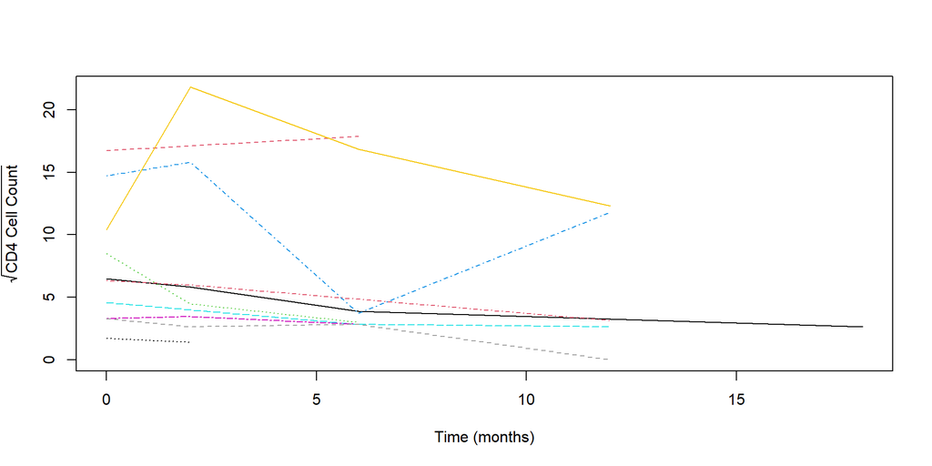

## Joint model of interest

$$\begin{aligned}
y_{i}(t) &= \underbrace{\beta_0 +\beta_1t + \beta_2\{t \times \text{ddI}_i\} + b_{i0} + b_{i1}t}_{m_{i}(t)} + \epsilon_{i}(t)
\\
h_{i}(t) &= h_{0}(t)\exp \{\gamma \text{ddI}_i + \alpha m_{i}(t)\}
\end{aligned}$$

## Joint model with `JM` package

- First, fit longitudinal submodel

```r
jmlong <- lme(CD4 ~ obstime + obstime:drug,
              random = ~ obstime | patient,
              data = aids)
```

- Next, fit survival submodel

```r
jmcox <- coxph(Surv(Time, death) ~ drug, x = TRUE,
               data = aids.id)
```

- Finally, fit joint model with piecewise baseline hazard (other options are available)

```r
jmaids <- jointModel(jmlong, jmcox, timeVar = "obstime",
                     method = "piecewise-PH-aGH")
```

## Joint model with `JM` package

```r
summary(jmaids)
```

```
Call:
jointModel(lmeObject = jmlong, survObject = jmcox, timeVar = "obstime",
    method = "piecewise-PH-aGH")

Data Descriptives:
Longitudinal Process        Event Process
Number of Observations: 1405    Number of Events: 188 (40.3%)
Number of Groups: 467

Joint Model Summary:
Longitudinal Process: Linear mixed-effects model
Event Process: Relative risk model with piecewise-constant
        baseline risk function
Parameterization: Time-dependent

   log.Lik      AIC      BIC
 -4328.261 8688.523 8754.864

Variance Components:
             StdDev    Corr
(Intercept)  4.5839  (Intr)
obstime      0.1822 -0.0468
Residual     1.7377

Coefficients:
Longitudinal Process
                  Value Std.Err z-value p-value
(Intercept)      7.2203  0.2218 32.5537 <0.0001
obstime         -0.1917  0.0217 -8.8374 <0.0001
obstime:drugddI  0.0116  0.0302  0.3834  0.7014

Event Process
            Value Std.Err  z-value p-value
drugddI    0.3348  0.1565   2.1397  0.0324
Assoct    -0.2875  0.0359  -8.0141 <0.0001
log(xi.1) -2.5438  0.1913 -13.2953
log(xi.2) -2.2722  0.1784 -12.7328
log(xi.3) -1.9554  0.2403  -8.1357
log(xi.4) -2.5011  0.3412  -7.3297
log(xi.5) -2.4152  0.3156  -7.6531
log(xi.6) -2.4018  0.4007  -5.9941
log(xi.7) -2.4239  0.5301  -4.5725

Integration:
method: (pseudo) adaptive Gauss-Hermite
quadrature points: 5

Optimization:
Convergence: 0
```

**Interpretation of the survival model**

- The hazard of death is 1.40 (95% CI: 1.03; 1.90) times higher among patients receiving ddI compared to patients receiving ddC
- One unit **decrease** in CD4 cell count corresponds to a 1.33-fold increase in the risk of death (95% CI: 1.24; 1.43)

## Comparison to standard LMM

The standard linear mixed effects model of
$$y_{i}(t) = \beta_0 +\beta_1t + \beta_2 \{t \times \text{ddI}_i\} + b_{i0} + b_{i1}t + \epsilon_{i}(t)$$
does not take into account the **potential** MNAR missing data mechanism due to death.

```r
lmmmod <- lme(CD4 ~ obstime + obstime:drug,
              random = ~ obstime | patient,
              data = aids)
```

## Comparison to standard LMM

Parameter estimates for **CD4 cell count**

|  | **JM** | **LMM** |
| --- | --- | --- |
|  | $\hat\beta$ (SE) | $\hat\beta$ (SE) |
| Time | -0.19 (0.02) | -0.16 (0.02) |
| Treat:Time | 0.012 (0.03) | 0.028 (0.03) |

Expected values of **CD4 cell count**

|  | **JM** | **LMM** |
| --- | --- | --- |
| $E(Y\|ddI=0)$ | $7.220-0.192t$ | $7.189-0.163t$ |
| $E(Y\|ddI=1)$ | $7.220-0.180t$ | $7.189-0.135t$ |

- Because JM assumes that drop-out process is informative, it is often used as a **sensitivity analysis**
- If the parameter estimates and the standard errors are similar, then we may be able to conclude that the drop-out process is non-informative
- Why not use JM as the main analysis?

## Conclusion on JM

The bivariate Joint Model for a Longitudinal Outcome and a Terminal Time-to-Event Outcome is useful to

- Account for **endogenous** time-dependent variables
- Model **joint association** between a longitudinal and time-to-event processes
- Account for **informative dropout** from longitudinal process
- Get better estimation

## Conclusion on missing data

- The literature on dealing with dropouts in longitudinal studies, and missing data in correlated data, is fast-growing
  - Keep up with the literature!
- If possible, **avoid** missing data
  - How can we avoid individuals from dropping out of the study?
- Sensitivity analysis is crucial